# Risk Factor Analysis

## Outcome Variable

**Outcome Variable:** wasted

## Predictor Variables

**Intervention Variable:** gagebrth

**Adjustment Set:**

- arm
- sex
- W_mage
- meducyrs
- feducyrs
- hhwealth_quart
- brthmon
- W_parity
- impsan
- delta_W_mage
- delta_meducyrs
- delta_feducyrs
- delta_hhwealth_quart
- delta_brthmon
- delta_W_parity
- delta_impsan

## Stratifying Variables

The analysis was stratified on these variable(s):

- agecat
- studyid
- country

## Data Summary

| agecat | studyid | country | gagebrth | wasted | n_cell | n |
| --- | --- | --- | --- | --- | --- | --- |
| Birth | ki1000108-CMC-V-BCS-2002 | INDIA | Full or late term | 0 | 47 | 86 |
| Birth | ki1000108-CMC-V-BCS-2002 | INDIA | Full or late term | 1 | 6 | 86 |
| Birth | ki1000108-CMC-V-BCS-2002 | INDIA | Preterm | 0 | 8 | 86 |
| Birth | ki1000108-CMC-V-BCS-2002 | INDIA | Preterm | 1 | 3 | 86 |
| Birth | ki1000108-CMC-V-BCS-2002 | INDIA | Early term | 0 | 20 | 86 |
| Birth | ki1000108-CMC-V-BCS-2002 | INDIA | Early term | 1 | 2 | 86 |
| Birth | ki1000108-IRC | INDIA | Full or late term | 0 | 164 | 328 |
| Birth | ki1000108-IRC | INDIA | Full or late term | 1 | 49 | 328 |
| Birth | ki1000108-IRC | INDIA | Preterm | 0 | 19 | 328 |
| Birth | ki1000108-IRC | INDIA | Preterm | 1 | 13 | 328 |
| Birth | ki1000108-IRC | INDIA | Early term | 0 | 58 | 328 |
| Birth | ki1000108-IRC | INDIA | Early term | 1 | 25 | 328 |
| Birth | ki1000109-EE | PAKISTAN | Full or late term | 0 | 7 | 177 |
| Birth | ki1000109-EE | PAKISTAN | Full or late term | 1 | 2 | 177 |
| Birth | ki1000109-EE | PAKISTAN | Preterm | 0 | 118 | 177 |
| Birth | ki1000109-EE | PAKISTAN | Preterm | 1 | 14 | 177 |
| Birth | ki1000109-EE | PAKISTAN | Early term | 0 | 30 | 177 |
| Birth | ki1000109-EE | PAKISTAN | Early term | 1 | 6 | 177 |
| Birth | ki1017093c-NIH-Crypto | BANGLADESH | Full or late term | 0 | 141 | 707 |
| Birth | ki1017093c-NIH-Crypto | BANGLADESH | Full or late term | 1 | 19 | 707 |
| Birth | ki1017093c-NIH-Crypto | BANGLADESH | Preterm | 0 | 152 | 707 |
| Birth | ki1017093c-NIH-Crypto | BANGLADESH | Preterm | 1 | 88 | 707 |
| Birth | ki1017093c-NIH-Crypto | BANGLADESH | Early term | 0 | 242 | 707 |
| Birth | ki1017093c-NIH-Crypto | BANGLADESH | Early term | 1 | 65 | 707 |
| Birth | ki1101329-Keneba | GAMBIA | Full or late term | 0 | 528 | 1439 |
| Birth | ki1101329-Keneba | GAMBIA | Full or late term | 1 | 181 | 1439 |
| Birth | ki1101329-Keneba | GAMBIA | Preterm | 0 | 162 | 1439 |
| Birth | ki1101329-Keneba | GAMBIA | Preterm | 1 | 44 | 1439 |
| Birth | ki1101329-Keneba | GAMBIA | Early term | 0 | 396 | 1439 |
| Birth | ki1101329-Keneba | GAMBIA | Early term | 1 | 128 | 1439 |

[output cut: 162 more lines]

The following strata were considered:

- agecat: 24 months, studyid: ki1000108-CMC-V-BCS-2002, country: INDIA
- agecat: 24 months, studyid: ki1000108-IRC, country: INDIA
- agecat: 24 months, studyid: ki1000109-EE, country: PAKISTAN
- agecat: 24 months, studyid: ki1017093c-NIH-Crypto, country: BANGLADESH
- agecat: 24 months, studyid: ki1066203-TanzaniaChild2, country: TANZANIA, UNITED REPUBLIC OF
- agecat: 24 months, studyid: ki1101329-Keneba, country: GAMBIA
- agecat: 24 months, studyid: ki1119695-PROBIT, country: BELARUS
- agecat: 24 months, studyid: ki1135781-COHORTS, country: GUATEMALA
- agecat: 24 months, studyid: ki1135781-COHORTS, country: INDIA
- agecat: 24 months, studyid: ki1135781-COHORTS, country: PHILIPPINES
- agecat: 24 months, studyid: kiGH5241-JiVitA-3, country: BANGLADESH
- agecat: 6 months, studyid: ki1000108-CMC-V-BCS-2002, country: INDIA
- agecat: 6 months, studyid: ki1000108-IRC, country: INDIA
- agecat: 6 months, studyid: ki1000109-EE, country: PAKISTAN
- agecat: 6 months, studyid: ki1017093c-NIH-Crypto, country: BANGLADESH
- agecat: 6 months, studyid: ki1066203-TanzaniaChild2, country: TANZANIA, UNITED REPUBLIC OF
- agecat: 6 months, studyid: ki1101329-Keneba, country: GAMBIA
- agecat: 6 months, studyid: ki1119695-PROBIT, country: BELARUS
- agecat: 6 months, studyid: ki1135781-COHORTS, country: GUATEMALA
- agecat: 6 months, studyid: ki1135781-COHORTS, country: INDIA
- agecat: 6 months, studyid: ki1135781-COHORTS, country: PHILIPPINES
- agecat: 6 months, studyid: kiGH5241-JiVitA-3, country: BANGLADESH
- agecat: Birth, studyid: ki1000108-CMC-V-BCS-2002, country: INDIA
- agecat: Birth, studyid: ki1000108-IRC, country: INDIA
- agecat: Birth, studyid: ki1000109-EE, country: PAKISTAN
- agecat: Birth, studyid: ki1017093c-NIH-Crypto, country: BANGLADESH
- agecat: Birth, studyid: ki1101329-Keneba, country: GAMBIA
- agecat: Birth, studyid: ki1119695-PROBIT, country: BELARUS
- agecat: Birth, studyid: ki1135781-COHORTS, country: GUATEMALA
- agecat: Birth, studyid: ki1135781-COHORTS, country: INDIA
- agecat: Birth, studyid: ki1135781-COHORTS, country: PHILIPPINES
- agecat: Birth, studyid: kiGH5241-JiVitA-3, country: BANGLADESH

### Dropped Strata

Some strata were dropped due to rare outcomes:

- agecat: Birth, studyid: ki1000108-CMC-V-BCS-2002, country: INDIA
- agecat: Birth, studyid: ki1000109-EE, country: PAKISTAN
- agecat: 6 months, studyid: ki1000109-EE, country: PAKISTAN
- agecat: 6 months, studyid: ki1017093c-NIH-Crypto, country: BANGLADESH
- agecat: 6 months, studyid: ki1135781-COHORTS, country: GUATEMALA
- agecat: 24 months, studyid: ki1000108-CMC-V-BCS-2002, country: INDIA
- agecat: 24 months, studyid: ki1000109-EE, country: PAKISTAN
- agecat: 24 months, studyid: ki1017093c-NIH-Crypto, country: BANGLADESH
- agecat: 24 months, studyid: ki1066203-TanzaniaChild2, country: TANZANIA, UNITED REPUBLIC OF
- agecat: 24 months, studyid: ki1119695-PROBIT, country: BELARUS

## Methods Detail

We’re interested in the causal parameters $E[Y_a]$ for all values of $a \in \mathcal{A}$. These parameters represent the mean outcome if, possibly contrary to fact, we intervened to set all units to have $A=a$. Under the randomization and positivity assumptions, these are identified by the statistical parameters $\psi_a=E_W[E_{Y|A,W}(Y|A=a,W)]$. In addition, we’re interested in the mean of $Y$, $E[Y]$ under no intervention (the observed mean). We will estimate these parameters by using SuperLearner to fit the relevant likelihood factors – $E_{Y|A,W}(Y|A=a,W)$ and $p(A=a|W)$, and then updating our likelihood fit using a joint TMLE.

For unadjusted analyses ($W=\{\}$), initial likelihoods were estimated using Lrnr_glm to estimate the simple $E(Y|A)$ and Lrnr_mean to estimate $p(A)$. For adjusted analyses, a small library containing Lrnr_glmnet, Lrnr_xgboost, and Lrnr_mean was used.

Having estimated these parameters, we will then use the delta method to estimate relative risks and attributable risks relative to a prespecified baseline level of $A$.

# Results Detail

## Results Plots

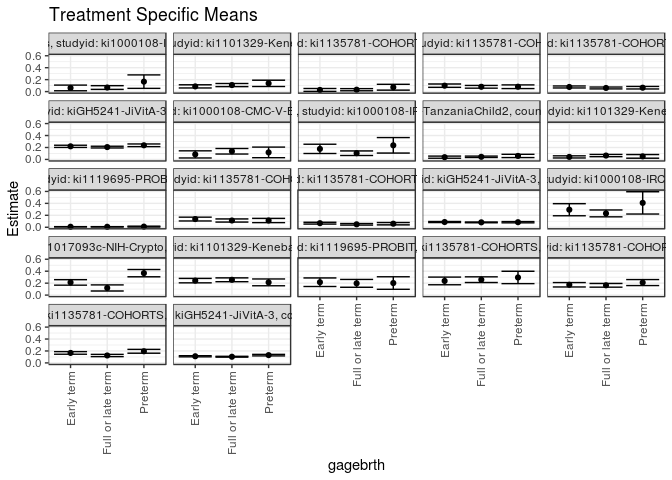

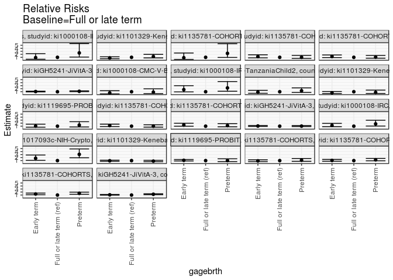

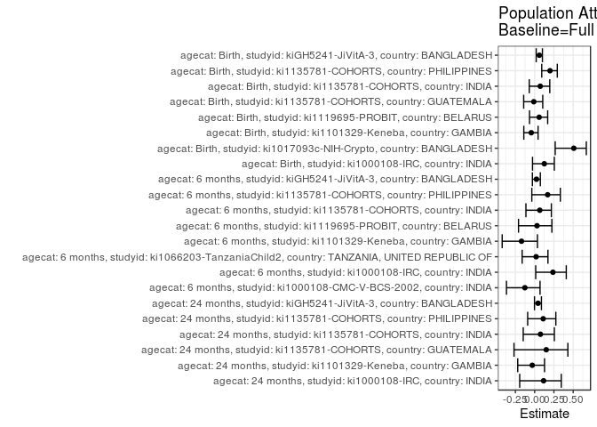

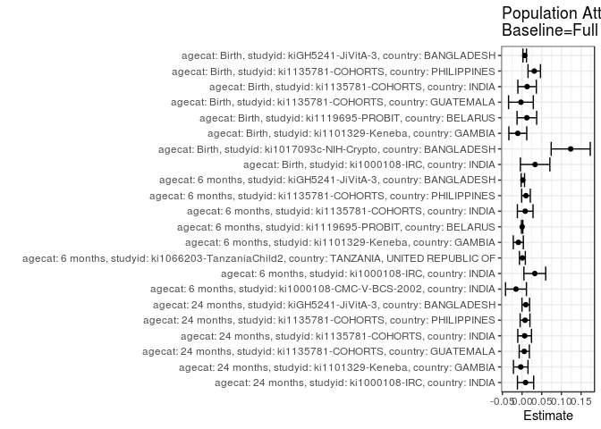

## Results Table

### Parameter: TSM

| agecat | studyid | country | intervention_level | baseline_level | estimate | ci_lower | ci_upper |
| --- | --- | --- | --- | --- | --- | --- | --- |
| Birth | ki1000108-IRC | INDIA | Full or late term | NA | 0.2320264 | 0.1743673 | 0.2896856 |
| Birth | ki1000108-IRC | INDIA | Preterm | NA | 0.4082223 | 0.2217492 | 0.5946954 |
| Birth | ki1000108-IRC | INDIA | Early term | NA | 0.2939235 | 0.1927454 | 0.3951016 |
| Birth | ki1017093c-NIH-Crypto | BANGLADESH | Full or late term | NA | 0.1196477 | 0.0685155 | 0.1707799 |
| Birth | ki1017093c-NIH-Crypto | BANGLADESH | Preterm | NA | 0.3675302 | 0.3063558 | 0.4287046 |
| Birth | ki1017093c-NIH-Crypto | BANGLADESH | Early term | NA | 0.2119516 | 0.1658357 | 0.2580675 |
| Birth | ki1101329-Keneba | GAMBIA | Full or late term | NA | 0.2561032 | 0.2238615 | 0.2883449 |
| Birth | ki1101329-Keneba | GAMBIA | Preterm | NA | 0.2128809 | 0.1562547 | 0.2695071 |
| Birth | ki1101329-Keneba | GAMBIA | Early term | NA | 0.2421772 | 0.2051485 | 0.2792059 |
| Birth | ki1119695-PROBIT | BELARUS | Full or late term | NA | 0.1965226 | 0.1308257 | 0.2622196 |
| Birth | ki1119695-PROBIT | BELARUS | Preterm | NA | 0.2017106 | 0.0968838 | 0.3065373 |
| Birth | ki1119695-PROBIT | BELARUS | Early term | NA | 0.2156369 | 0.1440847 | 0.2871891 |
| Birth | ki1135781-COHORTS | GUATEMALA | Full or late term | NA | 0.2580864 | 0.2103188 | 0.3058540 |
| Birth | ki1135781-COHORTS | GUATEMALA | Preterm | NA | 0.2951473 | 0.1915184 | 0.3987763 |
| Birth | ki1135781-COHORTS | GUATEMALA | Early term | NA | 0.2370437 | 0.1729247 | 0.3011626 |
| Birth | ki1135781-COHORTS | INDIA | Full or late term | NA | 0.1637410 | 0.1328930 | 0.1945889 |
| Birth | ki1135781-COHORTS | INDIA | Preterm | NA | 0.2096148 | 0.1596345 | 0.2595951 |
| Birth | ki1135781-COHORTS | INDIA | Early term | NA | 0.1728276 | 0.1363264 | 0.2093289 |
| Birth | ki1135781-COHORTS | PHILIPPINES | Full or late term | NA | 0.1245303 | 0.1054968 | 0.1435638 |
| Birth | ki1135781-COHORTS | PHILIPPINES | Preterm | NA | 0.1948531 | 0.1627141 | 0.2269920 |
| Birth | ki1135781-COHORTS | PHILIPPINES | Early term | NA | 0.1673665 | 0.1458049 | 0.1889280 |
| Birth | kiGH5241-JiVitA-3 | BANGLADESH | Full or late term | NA | 0.1034293 | 0.0966135 | 0.1102451 |
| Birth | kiGH5241-JiVitA-3 | BANGLADESH | Preterm | NA | 0.1304447 | 0.1177031 | 0.1431863 |
| Birth | kiGH5241-JiVitA-3 | BANGLADESH | Early term | NA | 0.1115761 | 0.1022260 | 0.1209262 |
| 6 months | ki1000108-CMC-V-BCS-2002 | INDIA | Full or late term | NA | 0.1367925 | 0.0904694 | 0.1831155 |
| 6 months | ki1000108-CMC-V-BCS-2002 | INDIA | Preterm | NA | 0.1176471 | 0.0290941 | 0.2062000 |
| 6 months | ki1000108-CMC-V-BCS-2002 | INDIA | Early term | NA | 0.0843373 | 0.0244665 | 0.1442082 |
| 6 months | ki1000108-IRC | INDIA | Full or late term | NA | 0.1041785 | 0.0660729 | 0.1422842 |
| 6 months | ki1000108-IRC | INDIA | Preterm | NA | 0.2361086 | 0.1063617 | 0.3658556 |
| 6 months | ki1000108-IRC | INDIA | Early term | NA | 0.1767912 | 0.0994992 | 0.2540833 |
| 6 months | ki1066203-TanzaniaChild2 | TANZANIA, UNITED REPUBLIC OF | Full or late term | NA | 0.0438247 | 0.0320555 | 0.0555938 |
| 6 months | ki1066203-TanzaniaChild2 | TANZANIA, UNITED REPUBLIC OF | Preterm | NA | 0.0585003 | 0.0313001 | 0.0857005 |
| 6 months | ki1066203-TanzaniaChild2 | TANZANIA, UNITED REPUBLIC OF | Early term | NA | 0.0376527 | 0.0198437 | 0.0554618 |
| 6 months | ki1101329-Keneba | GAMBIA | Full or late term | NA | 0.0647401 | 0.0457981 | 0.0836822 |
| 6 months | ki1101329-Keneba | GAMBIA | Preterm | NA | 0.0512087 | 0.0204261 | 0.0819914 |
| 6 months | ki1101329-Keneba | GAMBIA | Early term | NA | 0.0423825 | 0.0246180 | 0.0601471 |
| 6 months | ki1119695-PROBIT | BELARUS | Full or late term | NA | 0.0079940 | 0.0052977 | 0.0106903 |
| 6 months | ki1119695-PROBIT | BELARUS | Preterm | NA | 0.0108893 | 0.0041766 | 0.0176019 |
| 6 months | ki1119695-PROBIT | BELARUS | Early term | NA | 0.0083322 | 0.0061259 | 0.0105385 |
| 6 months | ki1135781-COHORTS | INDIA | Full or late term | NA | 0.1131495 | 0.0870276 | 0.1392714 |
| 6 months | ki1135781-COHORTS | INDIA | Preterm | NA | 0.1127991 | 0.0772969 | 0.1483013 |
| 6 months | ki1135781-COHORTS | INDIA | Early term | NA | 0.1372233 | 0.1054853 | 0.1689613 |
| 6 months | ki1135781-COHORTS | PHILIPPINES | Full or late term | NA | 0.0492300 | 0.0359937 | 0.0624662 |
| 6 months | ki1135781-COHORTS | PHILIPPINES | Preterm | NA | 0.0594832 | 0.0400168 | 0.0789496 |
| 6 months | ki1135781-COHORTS | PHILIPPINES | Early term | NA | 0.0685656 | 0.0535537 | 0.0835775 |
| 6 months | kiGH5241-JiVitA-3 | BANGLADESH | Full or late term | NA | 0.0823802 | 0.0758990 | 0.0888615 |
| 6 months | kiGH5241-JiVitA-3 | BANGLADESH | Preterm | NA | 0.0846620 | 0.0738731 | 0.0954509 |
| 6 months | kiGH5241-JiVitA-3 | BANGLADESH | Early term | NA | 0.0874799 | 0.0784481 | 0.0965116 |
| 24 months | ki1000108-IRC | INDIA | Full or late term | NA | 0.0680000 | 0.0367537 | 0.0992463 |
| 24 months | ki1000108-IRC | INDIA | Preterm | NA | 0.1666667 | 0.0538133 | 0.2795201 |
| 24 months | ki1000108-IRC | INDIA | Early term | NA | 0.0612245 | 0.0136980 | 0.1087510 |
| 24 months | ki1101329-Keneba | GAMBIA | Full or late term | NA | 0.1096129 | 0.0835059 | 0.1357198 |
| 24 months | ki1101329-Keneba | GAMBIA | Preterm | NA | 0.1380354 | 0.0851639 | 0.1909068 |
| 24 months | ki1101329-Keneba | GAMBIA | Early term | NA | 0.0871565 | 0.0604654 | 0.1138475 |
| 24 months | ki1135781-COHORTS | GUATEMALA | Full or late term | NA | 0.0318302 | 0.0140966 | 0.0495639 |
| 24 months | ki1135781-COHORTS | GUATEMALA | Preterm | NA | 0.0733945 | 0.0244008 | 0.1223881 |
| 24 months | ki1135781-COHORTS | GUATEMALA | Early term | NA | 0.0276243 | 0.0037298 | 0.0515188 |
| 24 months | ki1135781-COHORTS | INDIA | Full or late term | NA | 0.0804911 | 0.0577402 | 0.1032420 |
| 24 months | ki1135781-COHORTS | INDIA | Preterm | NA | 0.0816129 | 0.0510266 | 0.1121991 |
| 24 months | ki1135781-COHORTS | INDIA | Early term | NA | 0.0991860 | 0.0712897 | 0.1270823 |
| 24 months | ki1135781-COHORTS | PHILIPPINES | Full or late term | NA | 0.0607919 | 0.0454392 | 0.0761445 |
| 24 months | ki1135781-COHORTS | PHILIPPINES | Preterm | NA | 0.0649799 | 0.0438585 | 0.0861013 |
| 24 months | ki1135781-COHORTS | PHILIPPINES | Early term | NA | 0.0776244 | 0.0608135 | 0.0944352 |
| 24 months | kiGH5241-JiVitA-3 | BANGLADESH | Full or late term | NA | 0.2064667 | 0.1920958 | 0.2208376 |
| 24 months | kiGH5241-JiVitA-3 | BANGLADESH | Preterm | NA | 0.2365970 | 0.2144954 | 0.2586986 |
| 24 months | kiGH5241-JiVitA-3 | BANGLADESH | Early term | NA | 0.2195049 | 0.2011013 | 0.2379084 |

### Parameter: E(Y)

| agecat | studyid | country | intervention_level | baseline_level | estimate | ci_lower | ci_upper |
| --- | --- | --- | --- | --- | --- | --- | --- |
| Birth | ki1000108-IRC | INDIA | NA | NA | 0.2652439 | 0.2173954 | 0.3130924 |
| Birth | ki1017093c-NIH-Crypto | BANGLADESH | NA | NA | 0.2432815 | 0.2116319 | 0.2749310 |
| Birth | ki1101329-Keneba | GAMBIA | NA | NA | 0.2453092 | 0.2230705 | 0.2675480 |
| Birth | ki1119695-PROBIT | BELARUS | NA | NA | 0.2087491 | 0.1435025 | 0.2739957 |
| Birth | ki1135781-COHORTS | GUATEMALA | NA | NA | 0.2552448 | 0.2194833 | 0.2910062 |
| Birth | ki1135781-COHORTS | INDIA | NA | NA | 0.1765663 | 0.1552399 | 0.1978927 |
| Birth | ki1135781-COHORTS | PHILIPPINES | NA | NA | 0.1555324 | 0.1422803 | 0.1687844 |
| Birth | kiGH5241-JiVitA-3 | BANGLADESH | NA | NA | 0.1101917 | 0.1049992 | 0.1153842 |
| 6 months | ki1000108-CMC-V-BCS-2002 | INDIA | NA | NA | 0.1213873 | 0.0869266 | 0.1558480 |
| 6 months | ki1000108-IRC | INDIA | NA | NA | 0.1365979 | 0.1023826 | 0.1708133 |
| 6 months | ki1066203-TanzaniaChild2 | TANZANIA, UNITED REPUBLIC OF | NA | NA | 0.0446898 | 0.0354016 | 0.0539780 |
| 6 months | ki1101329-Keneba | GAMBIA | NA | NA | 0.0553130 | 0.0432217 | 0.0674042 |
| 6 months | ki1119695-PROBIT | BELARUS | NA | NA | 0.0082498 | 0.0066007 | 0.0098989 |
| 6 months | ki1135781-COHORTS | INDIA | NA | NA | 0.1211890 | 0.1035235 | 0.1388545 |
| 6 months | ki1135781-COHORTS | PHILIPPINES | NA | NA | 0.0592179 | 0.0502884 | 0.0681474 |
| 6 months | kiGH5241-JiVitA-3 | BANGLADESH | NA | NA | 0.0843705 | 0.0794524 | 0.0892887 |
| 24 months | ki1000108-IRC | INDIA | NA | NA | 0.0769231 | 0.0504429 | 0.1034032 |
| 24 months | ki1101329-Keneba | GAMBIA | NA | NA | 0.1063094 | 0.0885410 | 0.1240778 |
| 24 months | ki1135781-COHORTS | GUATEMALA | NA | NA | 0.0374813 | 0.0230560 | 0.0519065 |
| 24 months | ki1135781-COHORTS | INDIA | NA | NA | 0.0870570 | 0.0717143 | 0.1023997 |
| 24 months | ki1135781-COHORTS | PHILIPPINES | NA | NA | 0.0683690 | 0.0583283 | 0.0784097 |
| 24 months | kiGH5241-JiVitA-3 | BANGLADESH | NA | NA | 0.2159550 | 0.2060514 | 0.2258585 |

### Parameter: RR

| agecat | studyid | country | intervention_level | baseline_level | estimate | ci_lower | ci_upper |
| --- | --- | --- | --- | --- | --- | --- | --- |
| Birth | ki1000108-IRC | INDIA | Full or late term | Full or late term | 1.0000000 | 1.0000000 | 1.000000 |
| Birth | ki1000108-IRC | INDIA | Preterm | Full or late term | 1.7593786 | 1.0450105 | 2.962088 |
| Birth | ki1000108-IRC | INDIA | Early term | Full or late term | 1.2667673 | 0.8284438 | 1.937004 |
| Birth | ki1017093c-NIH-Crypto | BANGLADESH | Full or late term | Full or late term | 1.0000000 | 1.0000000 | 1.000000 |
| Birth | ki1017093c-NIH-Crypto | BANGLADESH | Preterm | Full or late term | 3.0717692 | 1.9415506 | 4.859913 |
| Birth | ki1017093c-NIH-Crypto | BANGLADESH | Early term | Full or late term | 1.7714634 | 1.0961967 | 2.862700 |
| Birth | ki1101329-Keneba | GAMBIA | Full or late term | Full or late term | 1.0000000 | 1.0000000 | 1.000000 |
| Birth | ki1101329-Keneba | GAMBIA | Preterm | Full or late term | 0.8312309 | 0.6193513 | 1.115594 |
| Birth | ki1101329-Keneba | GAMBIA | Early term | Full or late term | 0.9456236 | 0.7757973 | 1.152626 |
| Birth | ki1119695-PROBIT | BELARUS | Full or late term | Full or late term | 1.0000000 | 1.0000000 | 1.000000 |
| Birth | ki1119695-PROBIT | BELARUS | Preterm | Full or late term | 1.0263988 | 0.6563714 | 1.605028 |
| Birth | ki1119695-PROBIT | BELARUS | Early term | Full or late term | 1.0972624 | 0.8783555 | 1.370726 |
| Birth | ki1135781-COHORTS | GUATEMALA | Full or late term | Full or late term | 1.0000000 | 1.0000000 | 1.000000 |
| Birth | ki1135781-COHORTS | GUATEMALA | Preterm | Full or late term | 1.1435989 | 0.7688108 | 1.701093 |
| Birth | ki1135781-COHORTS | GUATEMALA | Early term | Full or late term | 0.9184663 | 0.6617279 | 1.274814 |
| Birth | ki1135781-COHORTS | INDIA | Full or late term | Full or late term | 1.0000000 | 1.0000000 | 1.000000 |
| Birth | ki1135781-COHORTS | INDIA | Preterm | Full or late term | 1.2801608 | 0.9452088 | 1.733809 |
| Birth | ki1135781-COHORTS | INDIA | Early term | Full or late term | 1.0554940 | 0.7951450 | 1.401087 |
| Birth | ki1135781-COHORTS | PHILIPPINES | Full or late term | Full or late term | 1.0000000 | 1.0000000 | 1.000000 |
| Birth | ki1135781-COHORTS | PHILIPPINES | Preterm | Full or late term | 1.5647045 | 1.2499783 | 1.958674 |
| Birth | ki1135781-COHORTS | PHILIPPINES | Early term | Full or late term | 1.3439822 | 1.1007677 | 1.640935 |
| Birth | kiGH5241-JiVitA-3 | BANGLADESH | Full or late term | Full or late term | 1.0000000 | 1.0000000 | 1.000000 |
| Birth | kiGH5241-JiVitA-3 | BANGLADESH | Preterm | Full or late term | 1.2611967 | 1.1190077 | 1.421453 |
| Birth | kiGH5241-JiVitA-3 | BANGLADESH | Early term | Full or late term | 1.0787668 | 0.9721102 | 1.197125 |
| 6 months | ki1000108-CMC-V-BCS-2002 | INDIA | Full or late term | Full or late term | 1.0000000 | 1.0000000 | 1.000000 |
| 6 months | ki1000108-CMC-V-BCS-2002 | INDIA | Preterm | Full or late term | 0.8600406 | 0.3767610 | 1.963234 |
| 6 months | ki1000108-CMC-V-BCS-2002 | INDIA | Early term | Full or late term | 0.6165351 | 0.2807839 | 1.353765 |
| 6 months | ki1000108-IRC | INDIA | Full or late term | Full or late term | 1.0000000 | 1.0000000 | 1.000000 |
| 6 months | ki1000108-IRC | INDIA | Preterm | Full or late term | 2.2663841 | 1.1706076 | 4.387890 |
| 6 months | ki1000108-IRC | INDIA | Early term | Full or late term | 1.6970023 | 0.9590247 | 3.002860 |
| 6 months | ki1066203-TanzaniaChild2 | TANZANIA, UNITED REPUBLIC OF | Full or late term | Full or late term | 1.0000000 | 1.0000000 | 1.000000 |
| 6 months | ki1066203-TanzaniaChild2 | TANZANIA, UNITED REPUBLIC OF | Preterm | Full or late term | 1.3348720 | 0.7801968 | 2.283889 |
| 6 months | ki1066203-TanzaniaChild2 | TANZANIA, UNITED REPUBLIC OF | Early term | Full or late term | 0.8591675 | 0.4986803 | 1.480245 |
| 6 months | ki1101329-Keneba | GAMBIA | Full or late term | Full or late term | 1.0000000 | 1.0000000 | 1.000000 |
| 6 months | ki1101329-Keneba | GAMBIA | Preterm | Full or late term | 0.7909887 | 0.4053359 | 1.543567 |
| 6 months | ki1101329-Keneba | GAMBIA | Early term | Full or late term | 0.6546557 | 0.3925864 | 1.091668 |
| 6 months | ki1119695-PROBIT | BELARUS | Full or late term | Full or late term | 1.0000000 | 1.0000000 | 1.000000 |
| 6 months | ki1119695-PROBIT | BELARUS | Preterm | Full or late term | 1.3621824 | 0.7434005 | 2.496018 |
| 6 months | ki1119695-PROBIT | BELARUS | Early term | Full or late term | 1.0423032 | 0.6562126 | 1.655555 |
| 6 months | ki1135781-COHORTS | INDIA | Full or late term | Full or late term | 1.0000000 | 1.0000000 | 1.000000 |
| 6 months | ki1135781-COHORTS | INDIA | Preterm | Full or late term | 0.9969033 | 0.6748345 | 1.472681 |
| 6 months | ki1135781-COHORTS | INDIA | Early term | Full or late term | 1.2127608 | 0.8755473 | 1.679851 |
| 6 months | ki1135781-COHORTS | PHILIPPINES | Full or late term | Full or late term | 1.0000000 | 1.0000000 | 1.000000 |
| 6 months | ki1135781-COHORTS | PHILIPPINES | Preterm | Full or late term | 1.2082722 | 0.7913186 | 1.844923 |
| 6 months | ki1135781-COHORTS | PHILIPPINES | Early term | Full or late term | 1.3927621 | 0.9849783 | 1.969369 |
| 6 months | kiGH5241-JiVitA-3 | BANGLADESH | Full or late term | Full or late term | 1.0000000 | 1.0000000 | 1.000000 |
| 6 months | kiGH5241-JiVitA-3 | BANGLADESH | Preterm | Full or late term | 1.0276981 | 0.8878621 | 1.189558 |
| 6 months | kiGH5241-JiVitA-3 | BANGLADESH | Early term | Full or late term | 1.0619041 | 0.9356664 | 1.205173 |
| 24 months | ki1000108-IRC | INDIA | Full or late term | Full or late term | 1.0000000 | 1.0000000 | 1.000000 |
| 24 months | ki1000108-IRC | INDIA | Preterm | Full or late term | 2.4509804 | 1.0813122 | 5.555569 |
| 24 months | ki1000108-IRC | INDIA | Early term | Full or late term | 0.9003601 | 0.3653015 | 2.219121 |
| 24 months | ki1101329-Keneba | GAMBIA | Full or late term | Full or late term | 1.0000000 | 1.0000000 | 1.000000 |
| 24 months | ki1101329-Keneba | GAMBIA | Preterm | Full or late term | 1.2592992 | 0.8024218 | 1.976310 |
| 24 months | ki1101329-Keneba | GAMBIA | Early term | Full or late term | 0.7951301 | 0.5398378 | 1.171151 |
| 24 months | ki1135781-COHORTS | GUATEMALA | Full or late term | Full or late term | 1.0000000 | 1.0000000 | 1.000000 |
| 24 months | ki1135781-COHORTS | GUATEMALA | Preterm | Full or late term | 2.3058104 | 0.9665200 | 5.500933 |
| 24 months | ki1135781-COHORTS | GUATEMALA | Early term | Full or late term | 0.8678637 | 0.3101816 | 2.428214 |
| 24 months | ki1135781-COHORTS | INDIA | Full or late term | Full or late term | 1.0000000 | 1.0000000 | 1.000000 |
| 24 months | ki1135781-COHORTS | INDIA | Preterm | Full or late term | 1.0139369 | 0.6342361 | 1.620955 |
| 24 months | ki1135781-COHORTS | INDIA | Early term | Full or late term | 1.2322609 | 0.8280753 | 1.833730 |
| 24 months | ki1135781-COHORTS | PHILIPPINES | Full or late term | Full or late term | 1.0000000 | 1.0000000 | 1.000000 |
| 24 months | ki1135781-COHORTS | PHILIPPINES | Preterm | Full or late term | 1.0688913 | 0.7083334 | 1.612981 |
| 24 months | ki1135781-COHORTS | PHILIPPINES | Early term | Full or late term | 1.2768872 | 0.9155418 | 1.780848 |
| 24 months | kiGH5241-JiVitA-3 | BANGLADESH | Full or late term | Full or late term | 1.0000000 | 1.0000000 | 1.000000 |
| 24 months | kiGH5241-JiVitA-3 | BANGLADESH | Preterm | Full or late term | 1.1459332 | 1.0203693 | 1.286949 |
| 24 months | kiGH5241-JiVitA-3 | BANGLADESH | Early term | Full or late term | 1.0631493 | 0.9515061 | 1.187892 |

### Parameter: PAR

| agecat | studyid | country | intervention_level | baseline_level | estimate | ci_lower | ci_upper |
| --- | --- | --- | --- | --- | --- | --- | --- |
| Birth | ki1000108-IRC | INDIA | Full or late term | NA | 0.0332175 | -0.0042489 | 0.0706838 |
| Birth | ki1017093c-NIH-Crypto | BANGLADESH | Full or late term | NA | 0.1236337 | 0.0740527 | 0.1732148 |
| Birth | ki1101329-Keneba | GAMBIA | Full or late term | NA | -0.0107939 | -0.0334864 | 0.0118985 |
| Birth | ki1119695-PROBIT | BELARUS | Full or late term | NA | 0.0122265 | -0.0126780 | 0.0371310 |
| Birth | ki1135781-COHORTS | GUATEMALA | Full or late term | NA | -0.0028416 | -0.0343240 | 0.0286407 |
| Birth | ki1135781-COHORTS | INDIA | Full or late term | NA | 0.0128253 | -0.0106242 | 0.0362749 |
| Birth | ki1135781-COHORTS | PHILIPPINES | Full or late term | NA | 0.0310021 | 0.0151716 | 0.0468326 |
| Birth | kiGH5241-JiVitA-3 | BANGLADESH | Full or late term | NA | 0.0067624 | 0.0023372 | 0.0111876 |
| 6 months | ki1000108-CMC-V-BCS-2002 | INDIA | Full or late term | NA | -0.0154052 | -0.0419343 | 0.0111240 |
| 6 months | ki1000108-IRC | INDIA | Full or late term | NA | 0.0324194 | 0.0047289 | 0.0601099 |
| 6 months | ki1066203-TanzaniaChild2 | TANZANIA, UNITED REPUBLIC OF | Full or late term | NA | 0.0008651 | -0.0065776 | 0.0083079 |
| 6 months | ki1101329-Keneba | GAMBIA | Full or late term | NA | -0.0094272 | -0.0221697 | 0.0033153 |
| 6 months | ki1119695-PROBIT | BELARUS | Full or late term | NA | 0.0002558 | -0.0015017 | 0.0020133 |
| 6 months | ki1135781-COHORTS | INDIA | Full or late term | NA | 0.0080395 | -0.0118669 | 0.0279459 |
| 6 months | ki1135781-COHORTS | PHILIPPINES | Full or late term | NA | 0.0099879 | -0.0009635 | 0.0209394 |
| 6 months | kiGH5241-JiVitA-3 | BANGLADESH | Full or late term | NA | 0.0019903 | -0.0023469 | 0.0063275 |
| 24 months | ki1000108-IRC | INDIA | Full or late term | NA | 0.0089231 | -0.0117124 | 0.0295586 |
| 24 months | ki1101329-Keneba | GAMBIA | Full or late term | NA | -0.0033034 | -0.0217232 | 0.0151163 |
| 24 months | ki1135781-COHORTS | GUATEMALA | Full or late term | NA | 0.0056510 | -0.0072744 | 0.0185765 |
| 24 months | ki1135781-COHORTS | INDIA | Full or late term | NA | 0.0065659 | -0.0108851 | 0.0240170 |
| 24 months | ki1135781-COHORTS | PHILIPPINES | Full or late term | NA | 0.0075772 | -0.0048746 | 0.0200289 |
| 24 months | kiGH5241-JiVitA-3 | BANGLADESH | Full or late term | NA | 0.0094883 | -0.0001973 | 0.0191739 |

### Parameter: PAF

| agecat | studyid | country | intervention_level | baseline_level | estimate | ci_lower | ci_upper |
| --- | --- | --- | --- | --- | --- | --- | --- |
| Birth | ki1000108-IRC | INDIA | Full or late term | NA | 0.1252337 | -0.0274550 | 0.2552315 |
| Birth | ki1017093c-NIH-Crypto | BANGLADESH | Full or late term | NA | 0.5081922 | 0.2665126 | 0.6702398 |
| Birth | ki1101329-Keneba | GAMBIA | Full or late term | NA | -0.0440013 | -0.1406932 | 0.0444944 |
| Birth | ki1119695-PROBIT | BELARUS | Full or late term | NA | 0.0585702 | -0.0666151 | 0.1690629 |
| Birth | ki1135781-COHORTS | GUATEMALA | Full or late term | NA | -0.0111330 | -0.1423152 | 0.1049843 |
| Birth | ki1135781-COHORTS | INDIA | Full or late term | NA | 0.0726375 | -0.0699485 | 0.1962219 |
| Birth | ki1135781-COHORTS | PHILIPPINES | Full or late term | NA | 0.1993289 | 0.0921308 | 0.2938694 |
| Birth | kiGH5241-JiVitA-3 | BANGLADESH | Full or late term | NA | 0.0613695 | 0.0202358 | 0.1007762 |
| 6 months | ki1000108-CMC-V-BCS-2002 | INDIA | Full or late term | NA | -0.1269093 | -0.3655987 | 0.0700603 |
| 6 months | ki1000108-IRC | INDIA | Full or late term | NA | 0.2373344 | 0.0137227 | 0.4102482 |
| 6 months | ki1066203-TanzaniaChild2 | TANZANIA, UNITED REPUBLIC OF | Full or late term | NA | 0.0193589 | -0.1621110 | 0.1724914 |
| 6 months | ki1101329-Keneba | GAMBIA | Full or late term | NA | -0.1704336 | -0.4212939 | 0.0361495 |
| 6 months | ki1119695-PROBIT | BELARUS | Full or late term | NA | 0.0310037 | -0.2093196 | 0.2235685 |
| 6 months | ki1135781-COHORTS | INDIA | Full or late term | NA | 0.0663387 | -0.1131687 | 0.2168991 |
| 6 months | ki1135781-COHORTS | PHILIPPINES | Full or late term | NA | 0.1686640 | -0.0366590 | 0.3333203 |
| 6 months | kiGH5241-JiVitA-3 | BANGLADESH | Full or late term | NA | 0.0235898 | -0.0291797 | 0.0736536 |
| 24 months | ki1000108-IRC | INDIA | Full or late term | NA | 0.1160000 | -0.1939710 | 0.3454983 |
| 24 months | ki1101329-Keneba | GAMBIA | Full or late term | NA | -0.0310738 | -0.2195914 | 0.1283037 |
| 24 months | ki1135781-COHORTS | GUATEMALA | Full or late term | NA | 0.1507692 | -0.2677534 | 0.4311253 |
| 24 months | ki1135781-COHORTS | INDIA | Full or late term | NA | 0.0754212 | -0.1482821 | 0.2555437 |
| 24 months | ki1135781-COHORTS | PHILIPPINES | Full or late term | NA | 0.1108272 | -0.0905724 | 0.2750337 |
| 24 months | kiGH5241-JiVitA-3 | BANGLADESH | Full or late term | NA | 0.0439365 | -0.0021905 | 0.0879404 |